# RLS modelling results

Alec

23 January, 2025

# Modelling of red sea urchins, red turban snails, and their ratio in Barkley Sound

## Loading in the data and other setup

For using the data I have downloaded clean data from my preliminary explorations that contains all of the exlanantory and response variables that I would like to use. I have also made a separate dataset where I have averaged the values for urchin, snail counts etc. for transects occurring at the same sites. I have also made a theme for all subsequent figures

## Modelling the log urchin to snail ratio

### Plotting the EVs against urchin to snail ratio

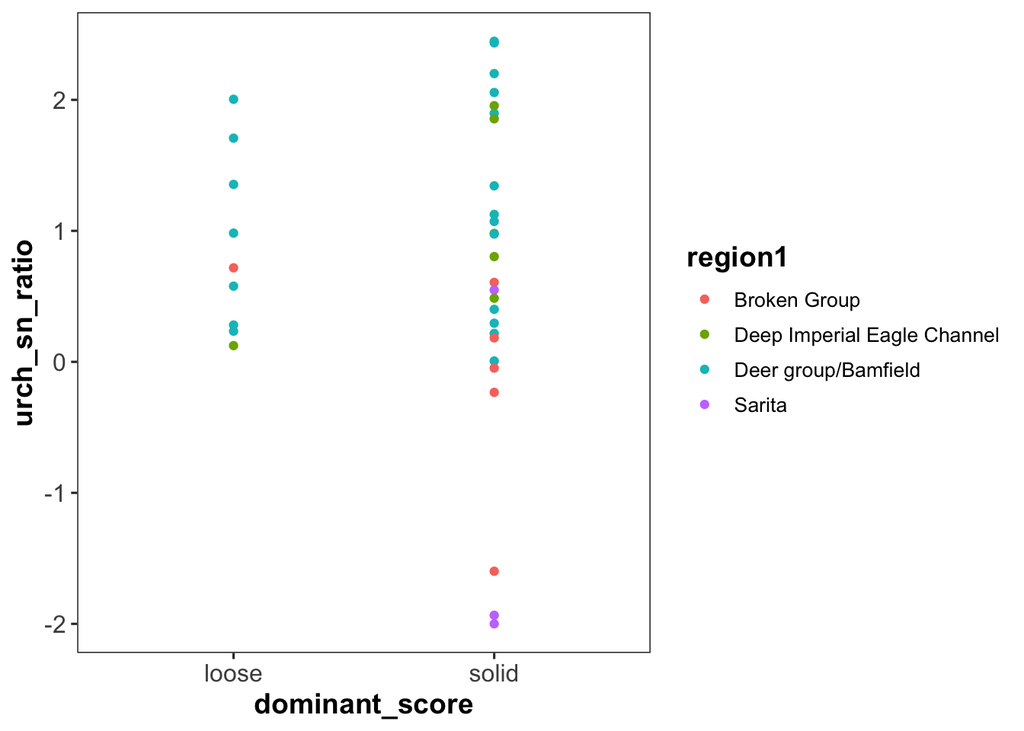

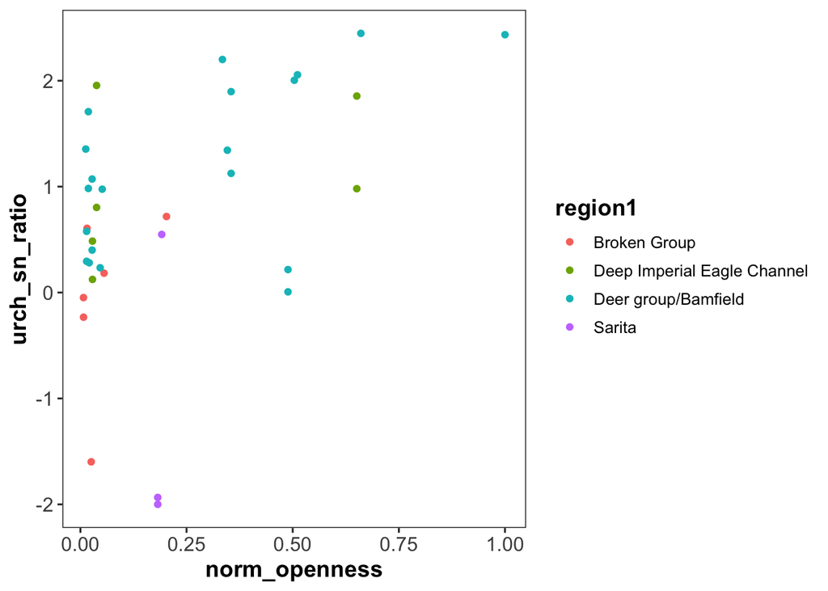

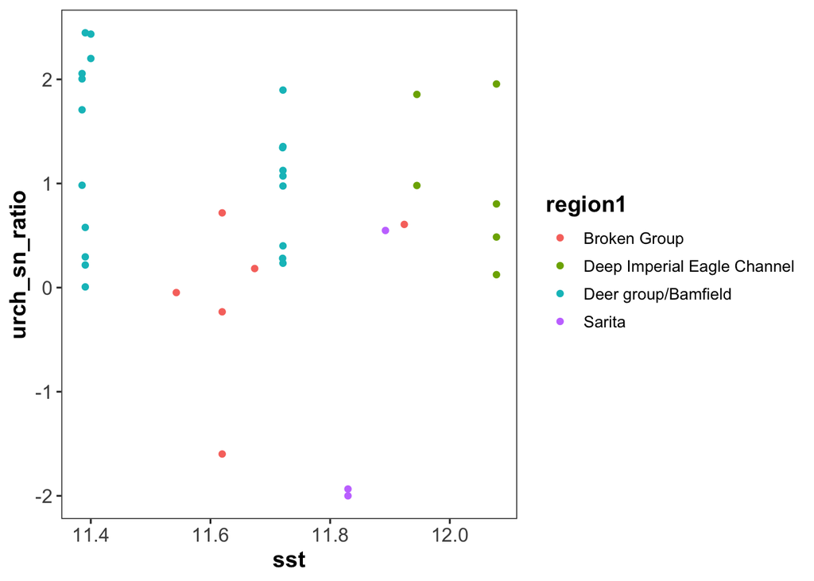

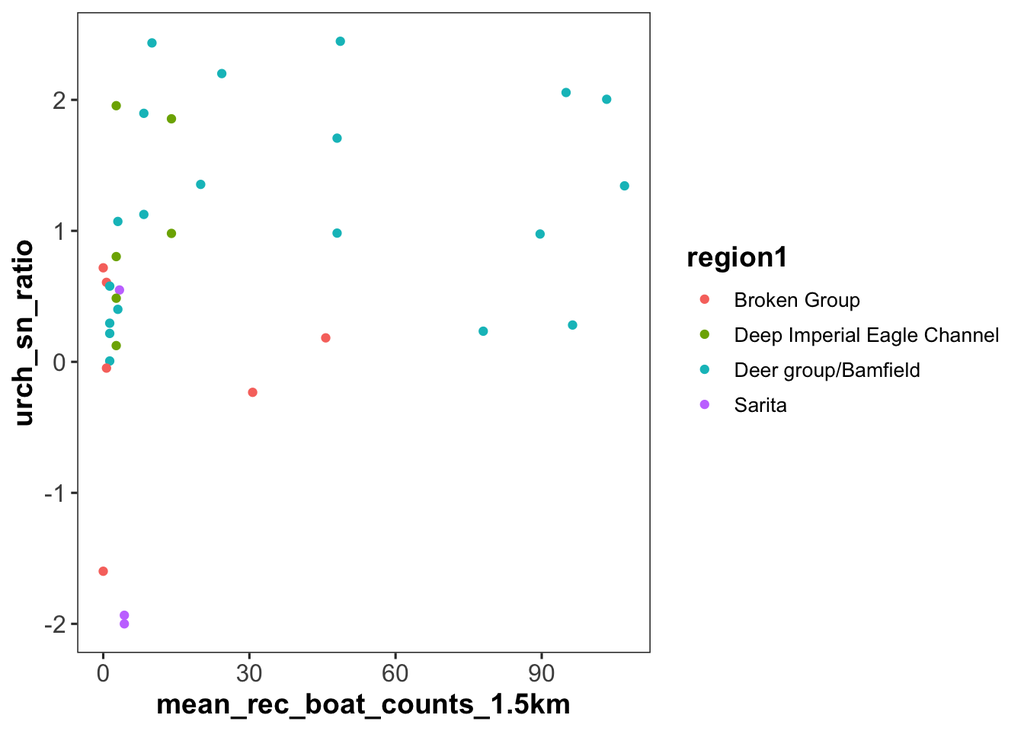

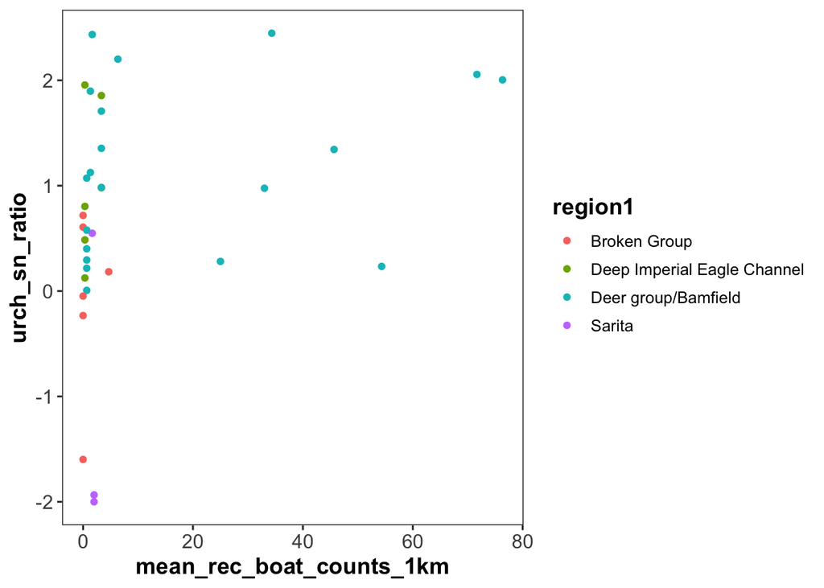

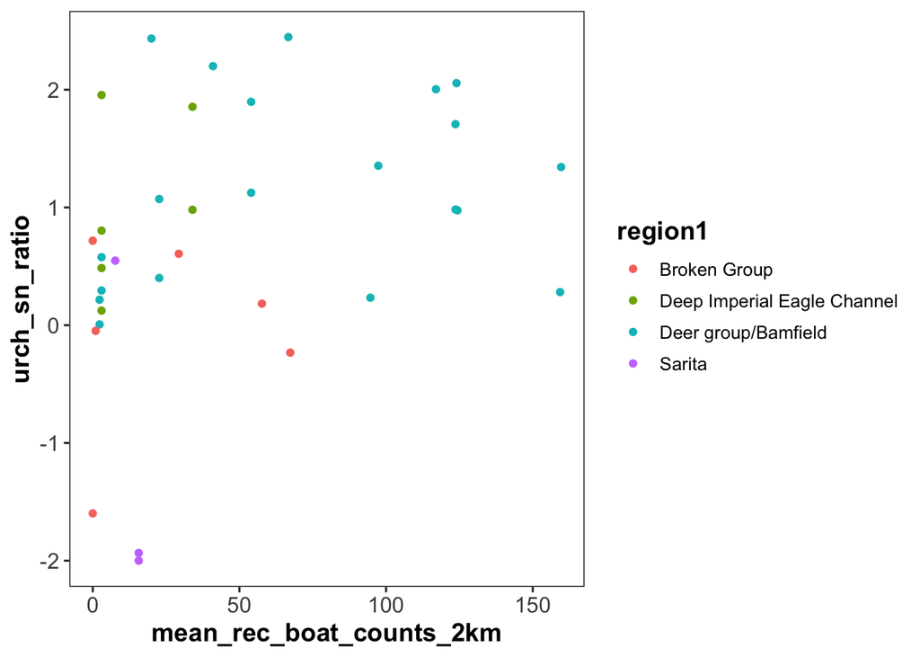

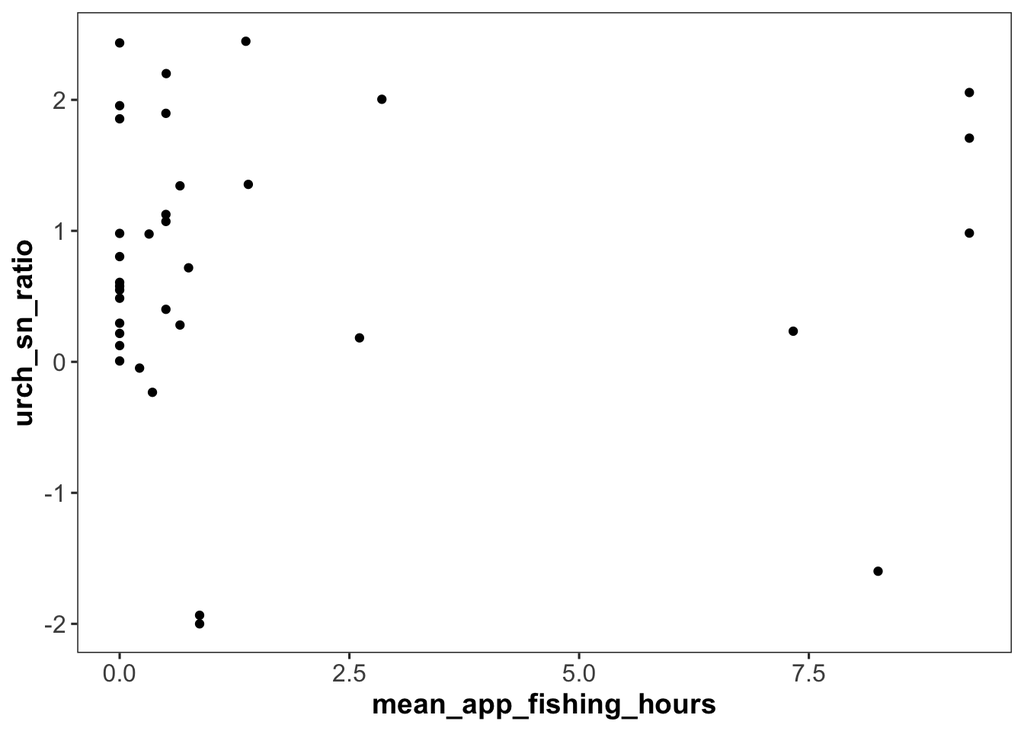

### Plotting the EVs against each other to look into concurvity

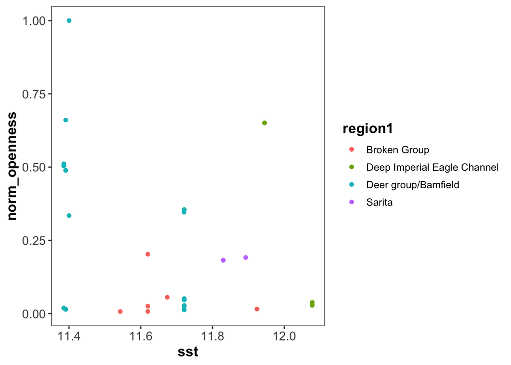

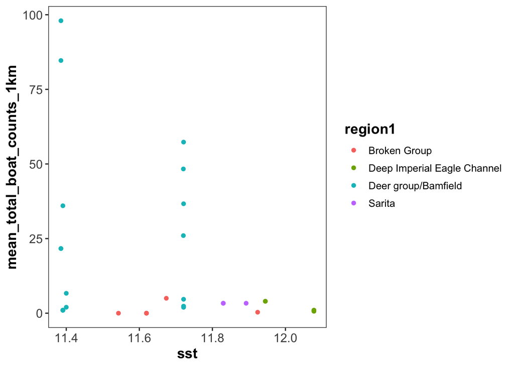

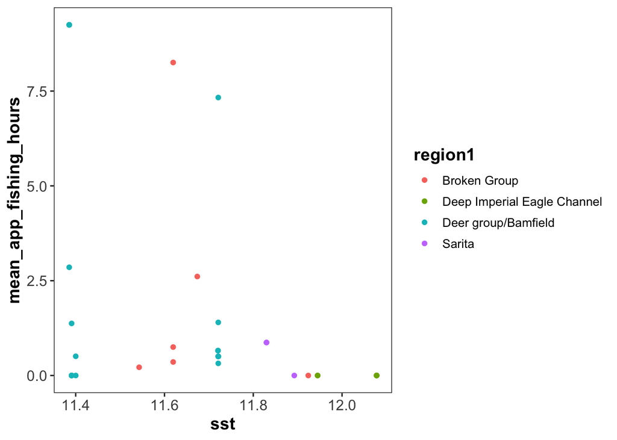

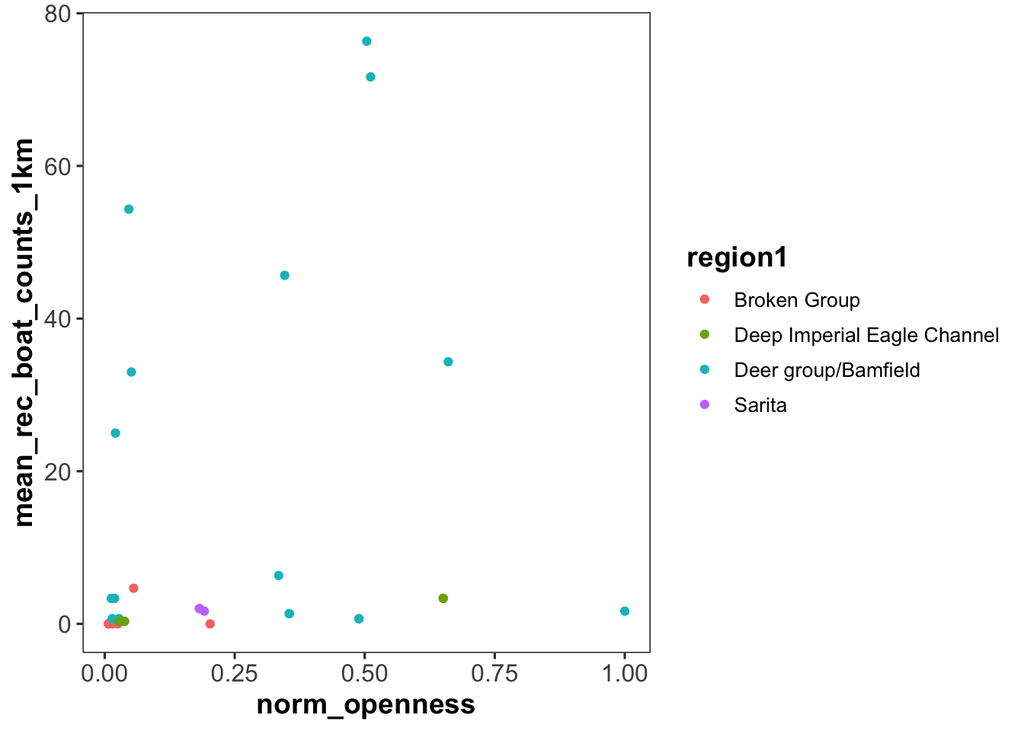

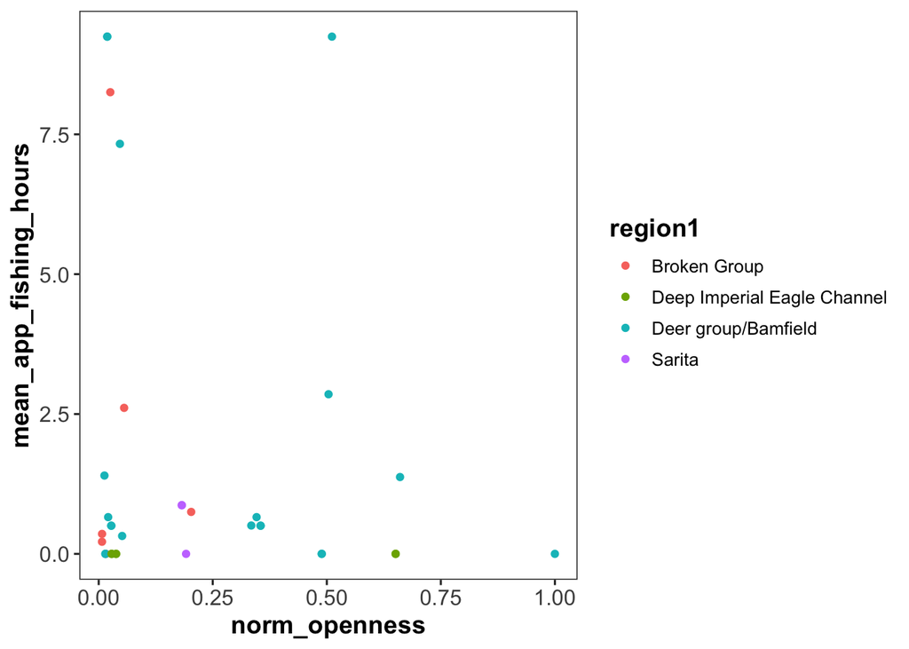

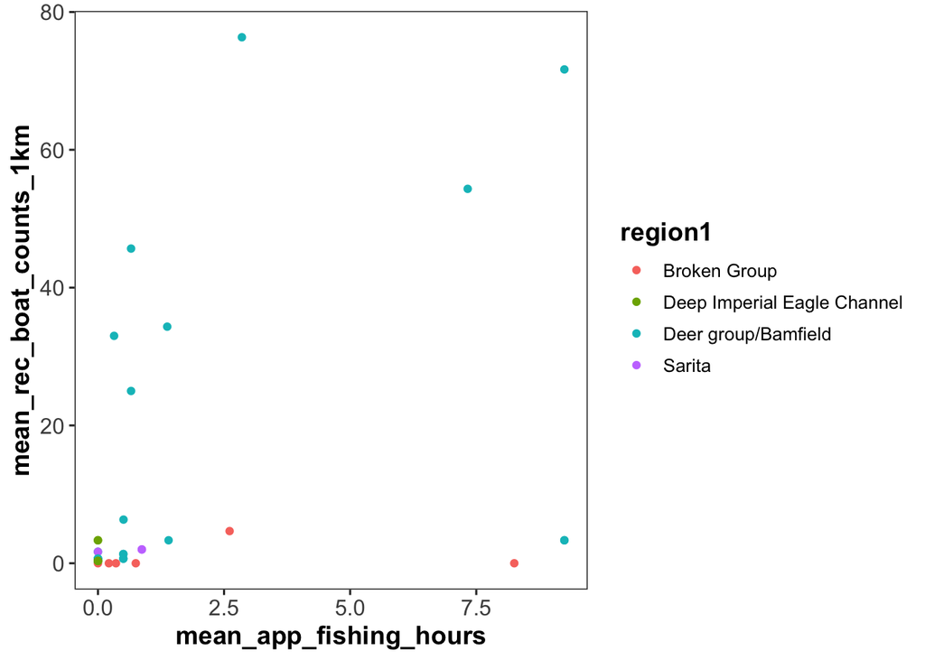

### Building GAMs to test the effects on the Urchin to snail ratio

#### Model with 1 km recreational boats

```r
total_mod_1km <- gam(urch_sn_ratio ~ s(sst_scale) +
                   s(norm_openness_scale) +
                   s(mean_rec_boat_counts_1km_scale)+
                   s(mean_app_fishing_hours_scale),
               data = env_mod_data,
               family = gaussian(link = "identity"),
               method = 'REML',
               select = TRUE)
```

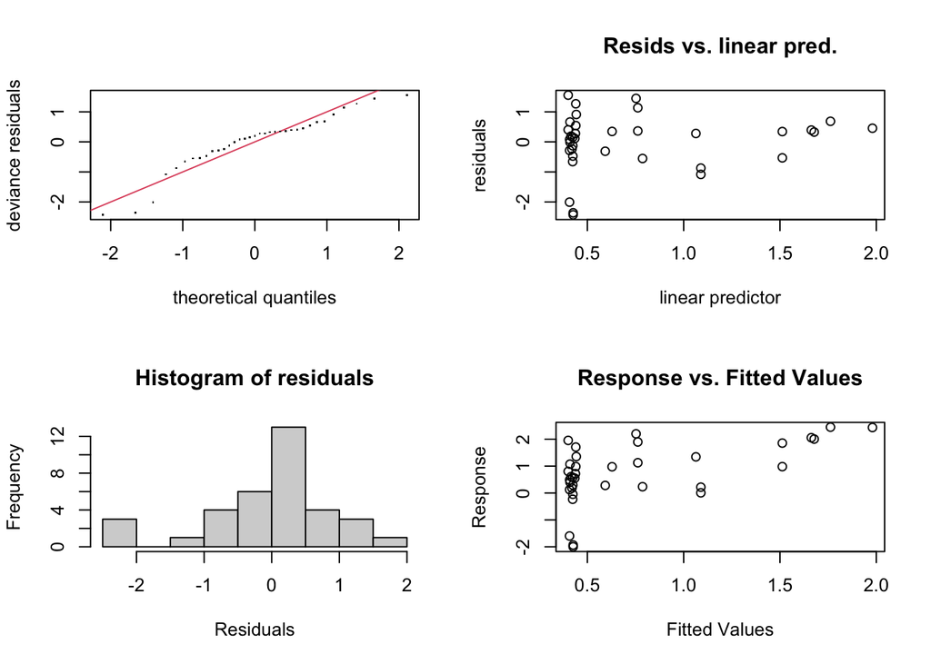

```
##
## Method: REML   Optimizer: outer newton
## full convergence after 14 iterations.
## Gradient range [-6.516633e-05,8.766407e-05]
## (score 50.77883 & scale 0.9295225).
## Hessian positive definite, eigenvalue range [2.120386e-06,17.04275].
## Model rank =  37 / 37
##
## Basis dimension (k) checking results. Low p-value (k-index<1) may
## indicate that k is too low, especially if edf is close to k'.
##
##                                         k'      edf k-index p-value
## s(sst_scale)                      9.00e+00 1.18e-02    0.75   0.045 *
## s(norm_openness_scale)            9.00e+00 1.59e+00    0.70   0.025 *
## s(mean_rec_boat_counts_1km_scale) 9.00e+00 5.69e-01    0.82   0.145
## s(mean_app_fishing_hours_scale)   9.00e+00 1.19e-05    0.76   0.045 *
## ---
## Signif. codes:  0 '***' 0.001 '**' 0.01 '*' 0.05 '.' 0.1 ' ' 1
```

[output not shown]

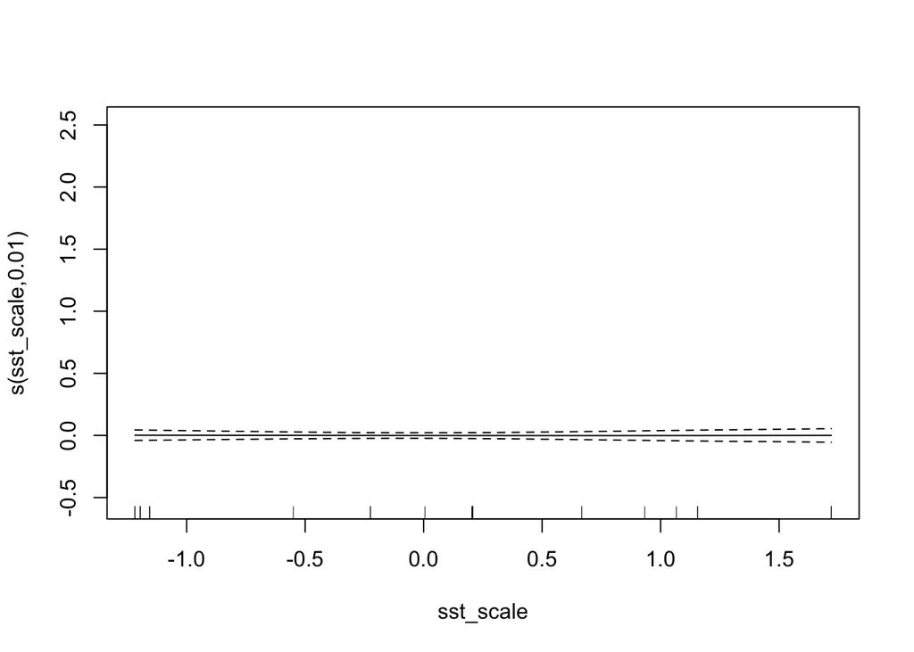

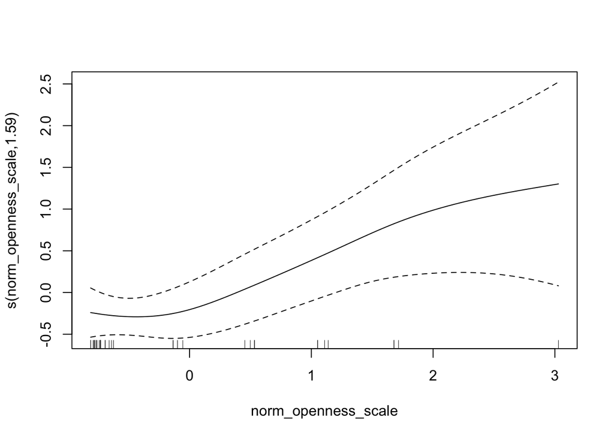

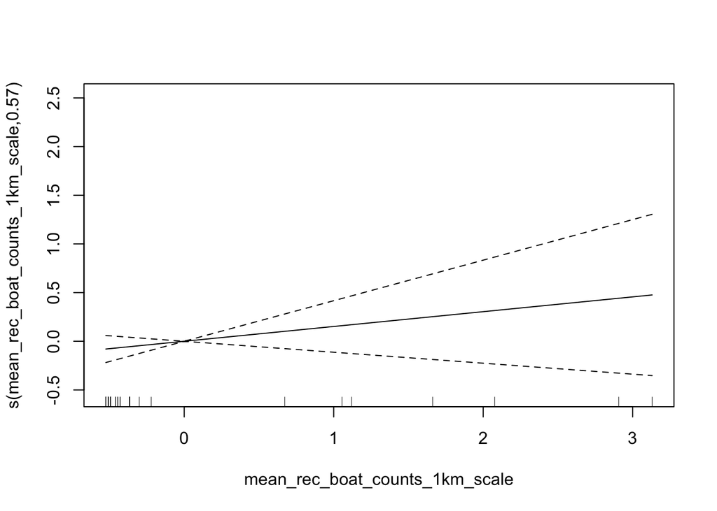

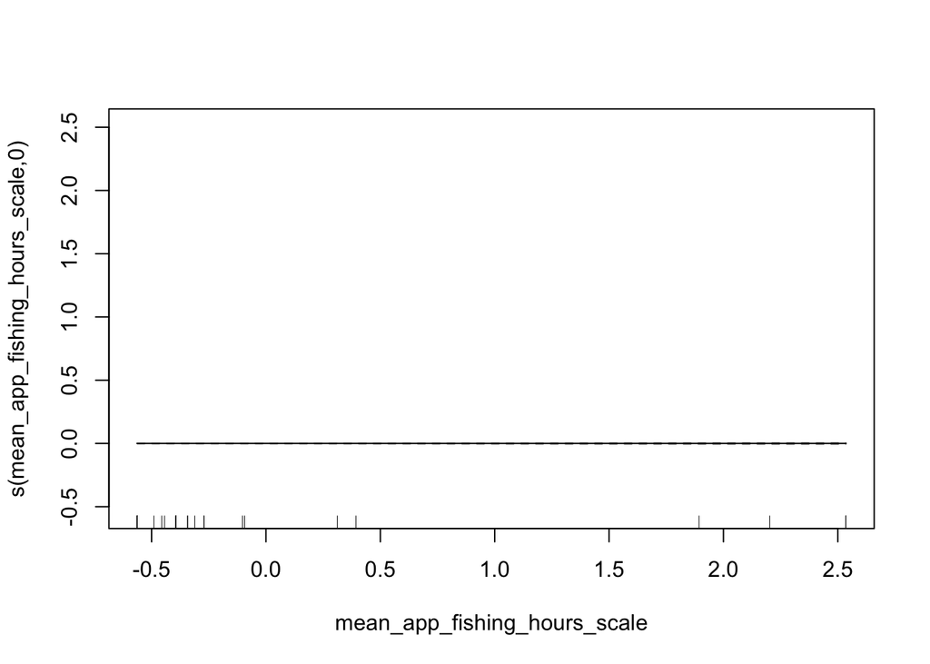

```
##
## Family: gaussian
## Link function: identity
##
## Formula:
## urch_sn_ratio ~ s(sst_scale) + s(norm_openness_scale) + s(mean_rec_boat_counts_1km_scale) +
##     s(mean_app_fishing_hours_scale)
##
## Parametric coefficients:
##             Estimate Std. Error t value Pr(>|t|)
## (Intercept)   0.7446     0.1630   4.569 6.99e-05 ***
## ---
## Signif. codes:  0 '***' 0.001 '**' 0.01 '*' 0.05 '.' 0.1 ' ' 1
##
## Approximate significance of smooth terms:
##                                         edf Ref.df     F p-value
## s(sst_scale)                      1.185e-02      9 0.001  0.3508
## s(norm_openness_scale)            1.586e+00      9 0.874  0.0106 *
## s(mean_rec_boat_counts_1km_scale) 5.689e-01      9 0.147  0.1328
## s(mean_app_fishing_hours_scale)   1.192e-05      9 0.000  0.8964
## ---
## Signif. codes:  0 '***' 0.001 '**' 0.01 '*' 0.05 '.' 0.1 ' ' 1
##
## R-sq.(adj) =  0.239   Deviance explained = 28.8%
## -REML = 50.779  Scale est. = 0.92952   n = 35
```

##### Testing the residuals for autocorrelation

```
##
##  Moran I test under randomisation
##
## data:  residuals_total_mod_1km
## weights: lw
## n reduced by no-neighbour observations
##
## Moran I statistic standard deviate = 1.987, p-value = 0.02346
## alternative hypothesis: greater
## sample estimates:
## Moran I statistic       Expectation          Variance
##        0.55217565       -0.05882353        0.09455605
```

```
##
##  Moran I test under randomisation
##
## data:  residuals_total_mod_1km
## weights: lw_inverse
##
## Moran I statistic standard deviate = 3.6042, p-value = 0.0001566
## alternative hypothesis: greater
## sample estimates:
## Moran I statistic       Expectation          Variance
##        0.57170425       -0.02941176        0.02781663
```

It appears that the residuals are autocorrelated. Will need to address this.

##### Testing the model for concurvity

```
## $worst
##                                           para s(sst_scale)
## para                              1.000000e+00 4.176841e-24
## s(sst_scale)                      4.182745e-24 1.000000e+00
## s(norm_openness_scale)            1.365135e-17 9.527043e-01
## s(mean_rec_boat_counts_1km_scale) 1.128657e-15 6.412812e-01
## s(mean_app_fishing_hours_scale)   6.545404e-17 9.996134e-01
##                                   s(norm_openness_scale)
## para                                        1.365142e-17
## s(sst_scale)                                9.527043e-01
## s(norm_openness_scale)                      1.000000e+00
## s(mean_rec_boat_counts_1km_scale)           9.941979e-01
## s(mean_app_fishing_hours_scale)             8.987165e-01
##                                   s(mean_rec_boat_counts_1km_scale)
## para                                                   1.128657e-15
## s(sst_scale)                                           6.412812e-01
## s(norm_openness_scale)                                 9.941979e-01
## s(mean_rec_boat_counts_1km_scale)                      1.000000e+00
## s(mean_app_fishing_hours_scale)                        9.999990e-01
##                                   s(mean_app_fishing_hours_scale)
## para                                                 6.545414e-17
## s(sst_scale)                                         9.996134e-01
## s(norm_openness_scale)                               8.987165e-01
## s(mean_rec_boat_counts_1km_scale)                    9.999990e-01
## s(mean_app_fishing_hours_scale)                      1.000000e+00
##
## $observed
##                                           para s(sst_scale)
## para                              1.000000e+00 1.560259e-30
## s(sst_scale)                      4.182745e-24 1.000000e+00
## s(norm_openness_scale)            1.365135e-17 5.103346e-01
## s(mean_rec_boat_counts_1km_scale) 1.128657e-15 3.066634e-01
## s(mean_app_fishing_hours_scale)   6.545404e-17 4.484178e-01
##                                   s(norm_openness_scale)
## para                                        5.073978e-24
## s(sst_scale)                                5.464512e-01
## s(norm_openness_scale)                      1.000000e+00
## s(mean_rec_boat_counts_1km_scale)           3.339818e-01
## s(mean_app_fishing_hours_scale)             2.016345e-01
##                                   s(mean_rec_boat_counts_1km_scale)
```

[output cut: 22 more lines]

```
## s(norm_openness_scale)                      1.000000e+00
## s(mean_rec_boat_counts_1km_scale)           2.832631e-01
## s(mean_app_fishing_hours_scale)             1.669555e-01
##                                   s(mean_rec_boat_counts_1km_scale)
## para                                                   5.525403e-18
## s(sst_scale)                                           2.865567e-01
## s(norm_openness_scale)                                 6.765577e-01
## s(mean_rec_boat_counts_1km_scale)                      1.000000e+00
## s(mean_app_fishing_hours_scale)                        6.045965e-01
##                                   s(mean_app_fishing_hours_scale)
## para                                                 5.634184e-21
## s(sst_scale)                                         4.095968e-01
## s(norm_openness_scale)                               2.390114e-01
## s(mean_rec_boat_counts_1km_scale)                    3.729543e-01
## s(mean_app_fishing_hours_scale)                      1.000000e+00
```

Some of the variables appear to have high concurvity scores in the worst case, but confidence intervals seem stable for the model plots. May need to get rid of the mean apparent fishing hours however. Since the concurvity was very high.

#### Model with 1.5 km recreational boats

```r
total_mod_1.5km <- gam(urch_sn_ratio ~ s(sst_scale) +
                   s(norm_openness_scale) +
                   s(mean_rec_boat_counts_1.5km_scale)+
                   s(mean_app_fishing_hours_scale),
               data = env_mod_data,
               family = gaussian(link = "identity"),
               method = 'REML',
               select = TRUE)
```

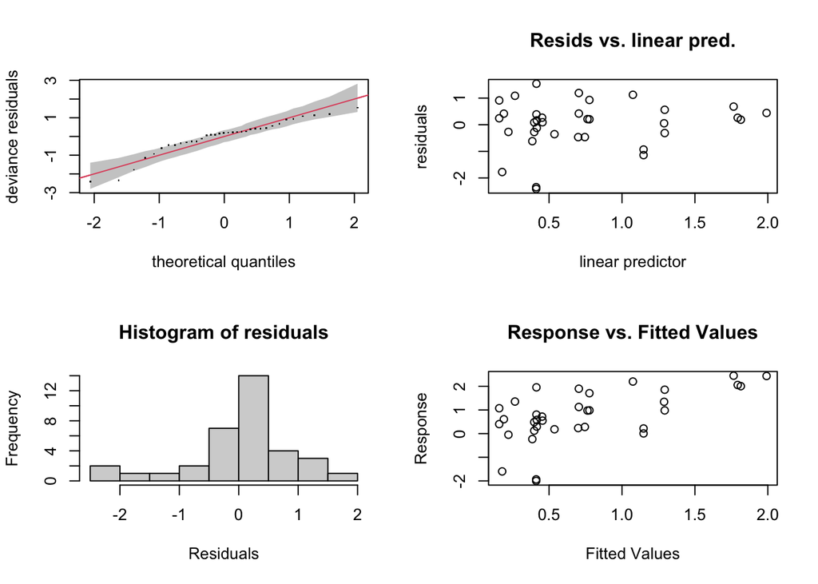

```
##
## Method: REML   Optimizer: outer newton
## full convergence after 17 iterations.
## Gradient range [-2.178803e-05,4.286005e-05]
## (score 50.30445 & scale 0.8816381).
## Hessian positive definite, eigenvalue range [1.03567e-06,17.03088].
## Model rank =  37 / 37
##
## Basis dimension (k) checking results. Low p-value (k-index<1) may
## indicate that k is too low, especially if edf is close to k'.
##
##                                           k'      edf k-index p-value
## s(sst_scale)                        9.00e+00 9.49e-01    0.70   0.030 *
## s(norm_openness_scale)              9.00e+00 8.70e-01    0.69   0.015 *
## s(mean_rec_boat_counts_1.5km_scale) 9.00e+00 8.23e-01    0.82   0.060 .
## s(mean_app_fishing_hours_scale)     9.00e+00 6.07e-06    0.75   0.050 *
## ---
## Signif. codes:  0 '***' 0.001 '**' 0.01 '*' 0.05 '.' 0.1 ' ' 1
```

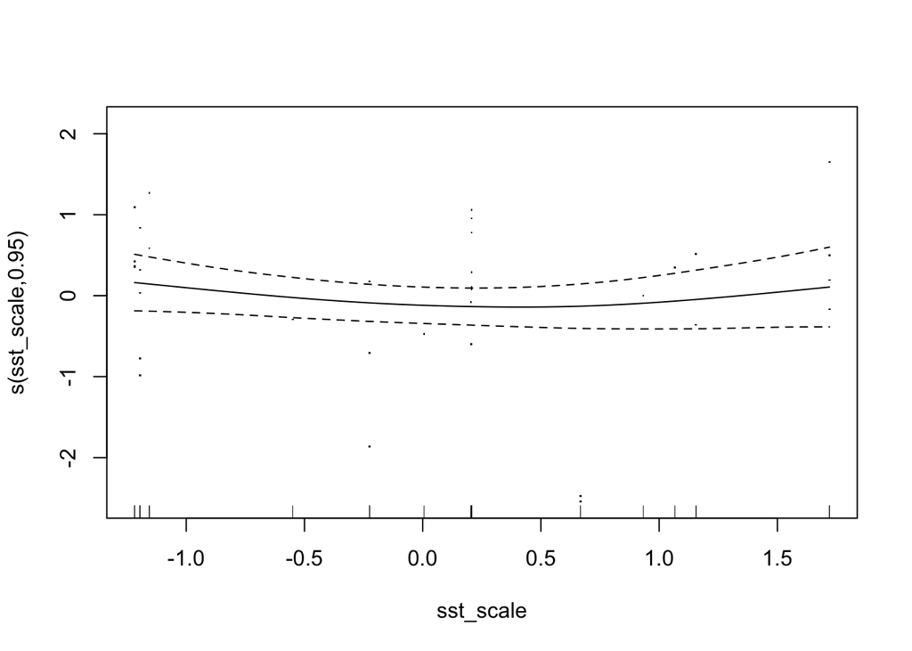

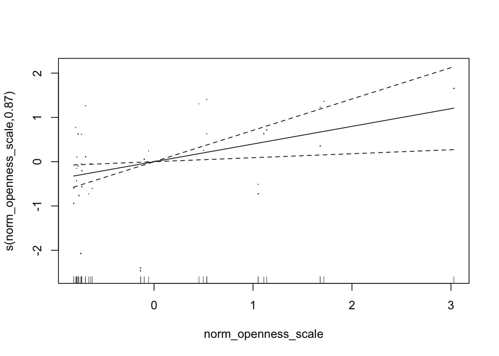

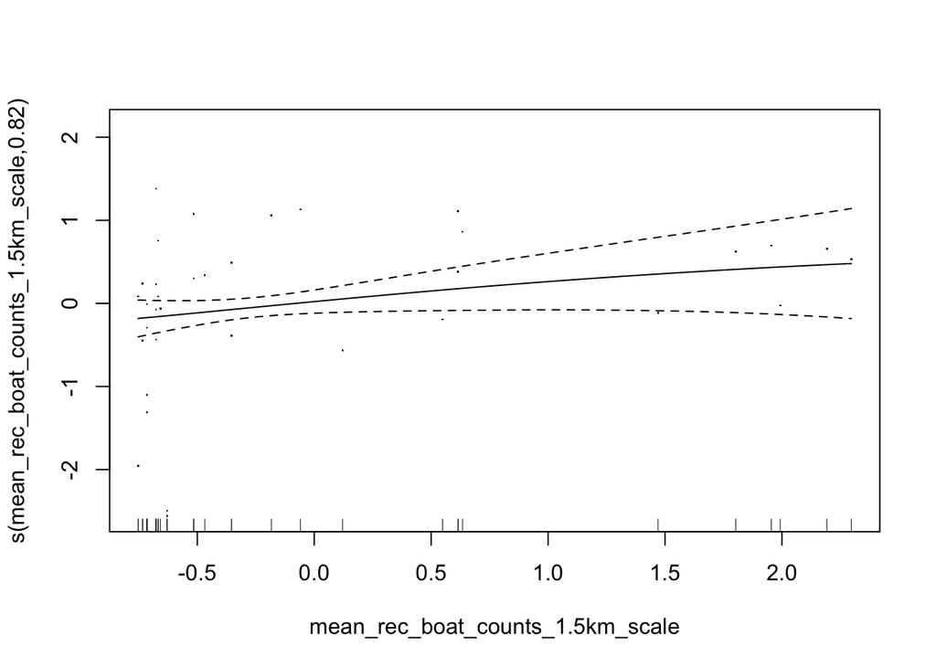

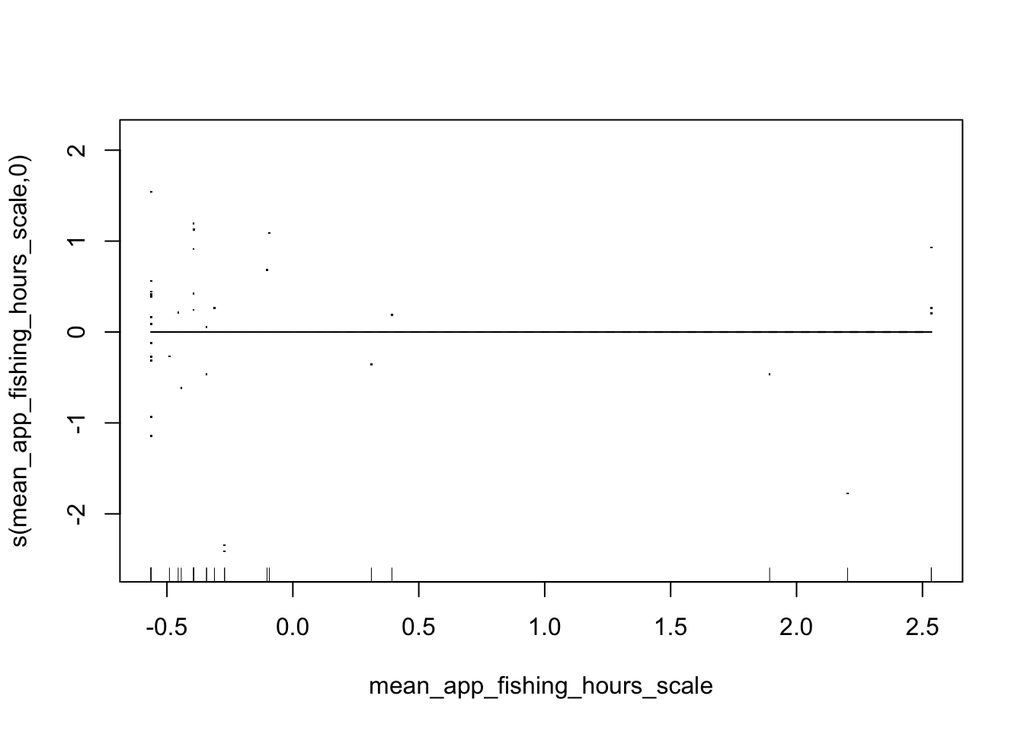

```
##
## Family: gaussian
## Link function: identity
##
## Formula:
## urch_sn_ratio ~ s(sst_scale) + s(norm_openness_scale) + s(mean_rec_boat_counts_1.5km_scale) +
##     s(mean_app_fishing_hours_scale)
##
## Parametric coefficients:
##             Estimate Std. Error t value Pr(>|t|)
## (Intercept)   0.7446     0.1587   4.691 5.07e-05 ***
## ---
## Signif. codes:  0 '***' 0.001 '**' 0.01 '*' 0.05 '.' 0.1 ' ' 1
##
## Approximate significance of smooth terms:
##                                           edf Ref.df     F p-value
## s(sst_scale)                        9.488e-01      9 0.172 0.20262
## s(norm_openness_scale)              8.696e-01      9 0.741 0.00856 **
## s(mean_rec_boat_counts_1.5km_scale) 8.228e-01      9 0.301 0.06578 .
## s(mean_app_fishing_hours_scale)     6.070e-06      9 0.000 0.68461
## ---
## Signif. codes:  0 '***' 0.001 '**' 0.01 '*' 0.05 '.' 0.1 ' ' 1
##
## R-sq.(adj) =  0.278   Deviance explained = 33.5%
## -REML = 50.304  Scale est. = 0.88164   n = 35
```

##### Testing the residuals for autocorrelation

```
##
##  Moran I test under randomisation
##
## data:  residuals_total_mod_1.5km
## weights: lw
## n reduced by no-neighbour observations
##
## Moran I statistic standard deviate = 2.0855, p-value = 0.01851
## alternative hypothesis: greater
## sample estimates:
## Moran I statistic       Expectation          Variance
##        0.58005381       -0.05882353        0.09384579
```

```
##
##  Moran I test under randomisation
##
## data:  residuals_total_mod_1.5km
## weights: lw_inverse
##
## Moran I statistic standard deviate = 3.7488, p-value = 8.885e-05
## alternative hypothesis: greater
## sample estimates:
## Moran I statistic       Expectation          Variance
##        0.59484988       -0.02941176        0.02773049
```

It appears that the residuals are autocorrelated. Will need to address this.

##### Testing the model for concurvity

```
## $worst
##                                             para s(sst_scale)
## para                                1.000000e+00 4.176841e-24
## s(sst_scale)                        4.182745e-24 1.000000e+00
## s(norm_openness_scale)              1.365135e-17 9.527043e-01
## s(mean_rec_boat_counts_1.5km_scale) 5.774936e-16 9.357699e-01
## s(mean_app_fishing_hours_scale)     6.545426e-17 9.996134e-01
##                                     s(norm_openness_scale)
## para                                          1.365142e-17
## s(sst_scale)                                  9.527043e-01
## s(norm_openness_scale)                        1.000000e+00
## s(mean_rec_boat_counts_1.5km_scale)           8.702294e-01
## s(mean_app_fishing_hours_scale)               8.987165e-01
##                                     s(mean_rec_boat_counts_1.5km_scale)
## para                                                       5.774935e-16
## s(sst_scale)                                               9.357699e-01
## s(norm_openness_scale)                                     8.702294e-01
## s(mean_rec_boat_counts_1.5km_scale)                        1.000000e+00
## s(mean_app_fishing_hours_scale)                            9.999576e-01
##                                     s(mean_app_fishing_hours_scale)
## para                                                   6.545414e-17
## s(sst_scale)                                           9.996134e-01
## s(norm_openness_scale)                                 8.987165e-01
## s(mean_rec_boat_counts_1.5km_scale)                    9.999576e-01
## s(mean_app_fishing_hours_scale)                        1.000000e+00
##
## $observed
##                                             para s(sst_scale)
## para                                1.000000e+00 5.751488e-32
## s(sst_scale)                        4.182745e-24 1.000000e+00
## s(norm_openness_scale)              1.365135e-17 4.300146e-01
## s(mean_rec_boat_counts_1.5km_scale) 5.774936e-16 2.217224e-01
## s(mean_app_fishing_hours_scale)     6.545426e-17 6.032375e-01
##                                     s(norm_openness_scale)
## para                                          2.808315e-33
## s(sst_scale)                                  4.675640e-01
## s(norm_openness_scale)                        1.000000e+00
## s(mean_rec_boat_counts_1.5km_scale)           4.564015e-01
## s(mean_app_fishing_hours_scale)               1.606805e-01
##                                     s(mean_rec_boat_counts_1.5km_scale)
```

[output cut: 22 more lines]

```
## s(norm_openness_scale)                        1.000000e+00
## s(mean_rec_boat_counts_1.5km_scale)           4.452391e-01
## s(mean_app_fishing_hours_scale)               1.669555e-01
##                                     s(mean_rec_boat_counts_1.5km_scale)
## para                                                       1.838027e-19
## s(sst_scale)                                               3.443672e-01
## s(norm_openness_scale)                                     4.041088e-01
## s(mean_rec_boat_counts_1.5km_scale)                        1.000000e+00
## s(mean_app_fishing_hours_scale)                            4.499604e-01
##                                     s(mean_app_fishing_hours_scale)
## para                                                   5.634184e-21
## s(sst_scale)                                           4.095968e-01
## s(norm_openness_scale)                                 2.390114e-01
## s(mean_rec_boat_counts_1.5km_scale)                    4.434674e-01
## s(mean_app_fishing_hours_scale)                        1.000000e+00
```

Some of the variables appear to have high concurvity scores in the worst case, but confidence intervals seem stable for the model plots. May need to get rid of the mean apparent fishing hours however. Since the concurvity was very high.

#### Model with 2 km recreational boats

```r
total_mod_2km <- gam(urch_sn_ratio ~ s(sst_scale) +
                   s(norm_openness_scale) +
                   s(mean_rec_boat_counts_2km_scale)+
                   s(mean_app_fishing_hours_scale),
               data = env_mod_data,
               family = gaussian(link = "identity"),
               method = 'REML',
               select = TRUE)
```

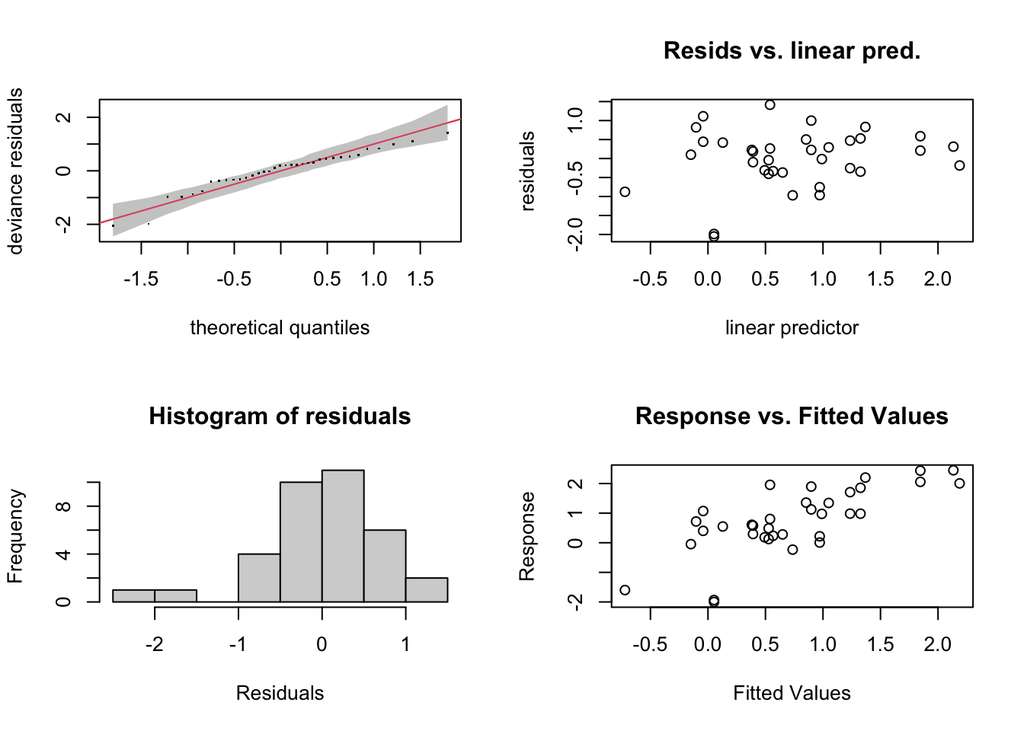

```
##
## Method: REML   Optimizer: outer newton
## full convergence after 15 iterations.
## Gradient range [-5.607833e-05,0.0001345764]
## (score 48.70881 & scale 0.6760163).
## Hessian positive definite, eigenvalue range [3.166065e-06,17.10249].
## Model rank =  37 / 37
##
## Basis dimension (k) checking results. Low p-value (k-index<1) may
## indicate that k is too low, especially if edf is close to k'.
##
##                                      k'   edf k-index p-value
## s(sst_scale)                      9.000 1.805    0.68   0.015 *
## s(norm_openness_scale)            9.000 0.835    0.70   0.035 *
## s(mean_rec_boat_counts_2km_scale) 9.000 1.742    0.83   0.085 .
## s(mean_app_fishing_hours_scale)   9.000 0.579    0.80   0.080 .
## ---
## Signif. codes:  0 '***' 0.001 '**' 0.01 '*' 0.05 '.' 0.1 ' ' 1
```

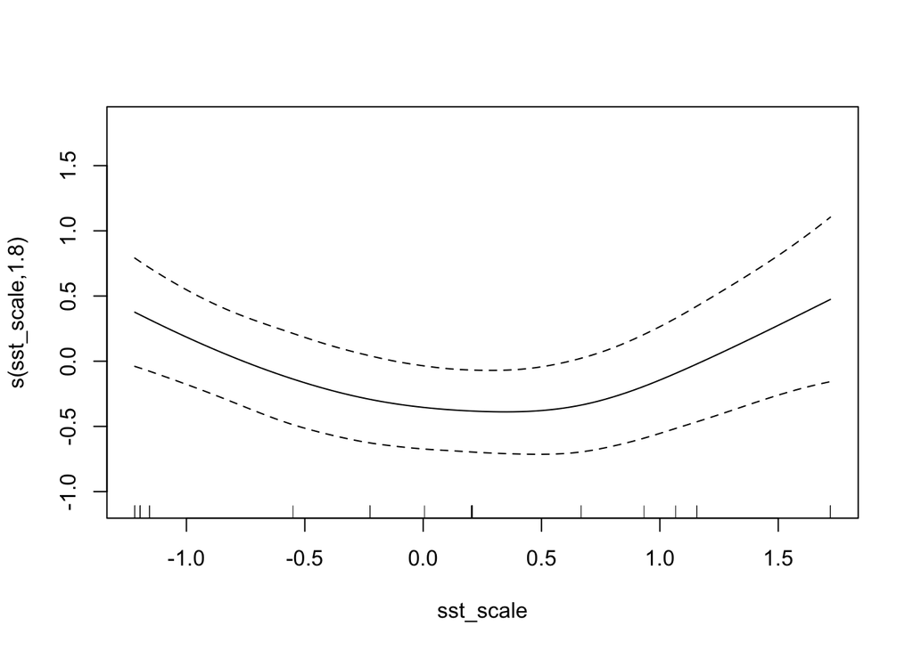

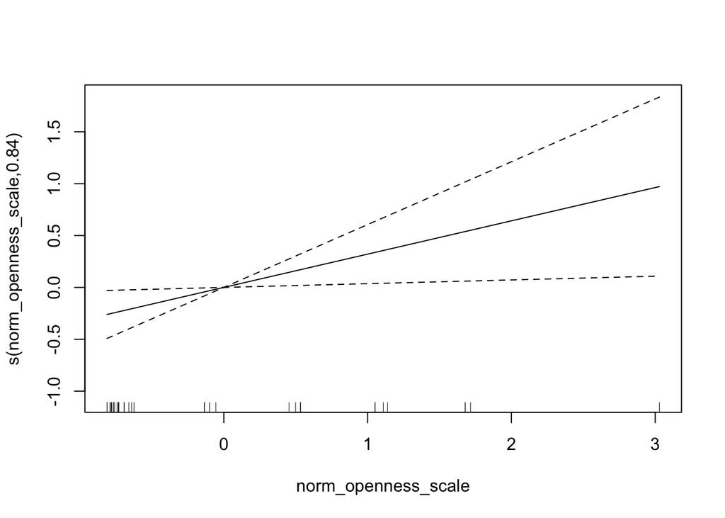

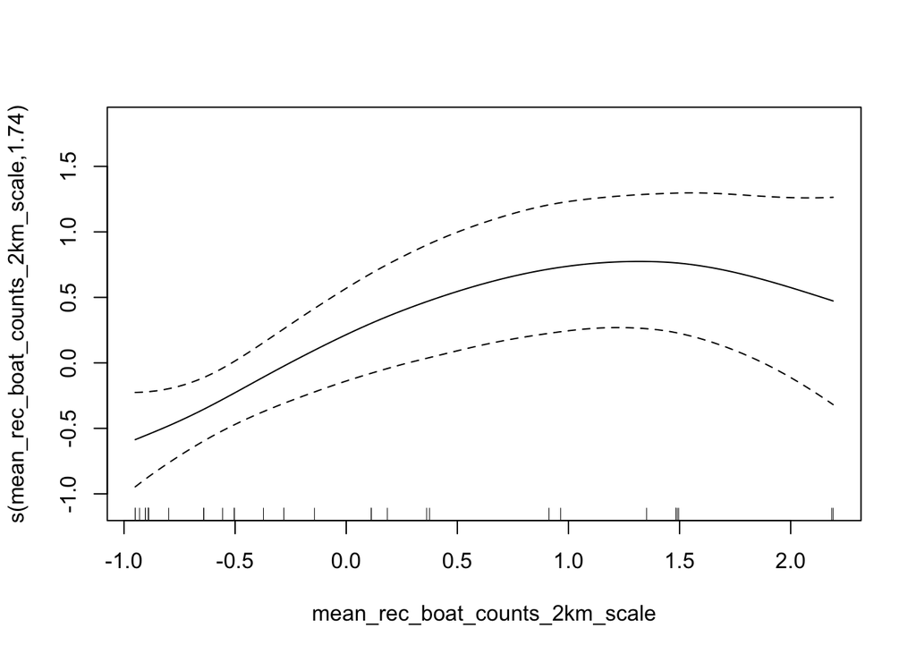

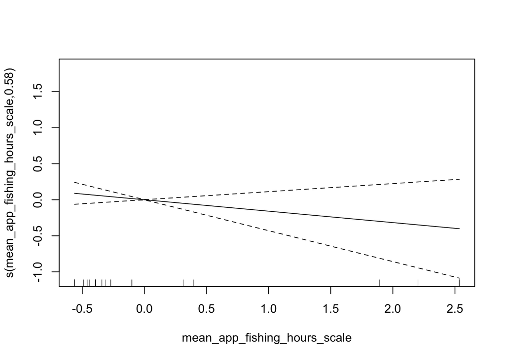

```
##
## Family: gaussian
## Link function: identity
##
## Formula:
## urch_sn_ratio ~ s(sst_scale) + s(norm_openness_scale) + s(mean_rec_boat_counts_2km_scale) +
##     s(mean_app_fishing_hours_scale)
##
## Parametric coefficients:
##             Estimate Std. Error t value Pr(>|t|)
## (Intercept)   0.7446     0.1390   5.357 9.36e-06 ***
## ---
## Signif. codes:  0 '***' 0.001 '**' 0.01 '*' 0.05 '.' 0.1 ' ' 1
##
## Approximate significance of smooth terms:
##                                      edf Ref.df     F p-value
## s(sst_scale)                      1.8049      9 0.801 0.02099 *
## s(norm_openness_scale)            0.8354      9 0.564 0.01595 *
## s(mean_rec_boat_counts_2km_scale) 1.7417      9 1.306 0.00206 **
## s(mean_app_fishing_hours_scale)   0.5788      9 0.153 0.12184
## ---
## Signif. codes:  0 '***' 0.001 '**' 0.01 '*' 0.05 '.' 0.1 ' ' 1
##
## R-sq.(adj) =  0.447   Deviance explained = 52.7%
## -REML = 48.709  Scale est. = 0.67602   n = 35
```

##### Testing the residuals for autocorrelation

```
##
##  Moran I test under randomisation
##
## data:  residuals_total_mod_2km
## weights: lw
## n reduced by no-neighbour observations
##
## Moran I statistic standard deviate = 2.0453, p-value = 0.02041
## alternative hypothesis: greater
## sample estimates:
## Moran I statistic       Expectation          Variance
##        0.57027933       -0.05882353        0.09461192
```

```
##
##  Moran I test under randomisation
##
## data:  residuals_total_mod_2km
## weights: lw_inverse
##
## Moran I statistic standard deviate = 3.5164, p-value = 0.0002187
## alternative hypothesis: greater
## sample estimates:
## Moran I statistic       Expectation          Variance
##        0.55713228       -0.02941176        0.02782341
```

It appears that the residuals are autocorrelated. Will need to address this.

##### Testing the model for concurvity

```
## $worst
##                                           para s(sst_scale)
## para                              1.000000e+00 4.176841e-24
## s(sst_scale)                      4.182745e-24 1.000000e+00
## s(norm_openness_scale)            1.365135e-17 9.527043e-01
## s(mean_rec_boat_counts_2km_scale) 7.219823e-16 8.949397e-01
## s(mean_app_fishing_hours_scale)   6.545446e-17 9.996134e-01
##                                   s(norm_openness_scale)
## para                                        1.365142e-17
## s(sst_scale)                                9.527043e-01
## s(norm_openness_scale)                      1.000000e+00
## s(mean_rec_boat_counts_2km_scale)           8.630857e-01
## s(mean_app_fishing_hours_scale)             8.987165e-01
##                                   s(mean_rec_boat_counts_2km_scale)
## para                                                   7.219824e-16
## s(sst_scale)                                           8.949397e-01
## s(norm_openness_scale)                                 8.630857e-01
## s(mean_rec_boat_counts_2km_scale)                      1.000000e+00
## s(mean_app_fishing_hours_scale)                        9.982199e-01
##                                   s(mean_app_fishing_hours_scale)
## para                                                 6.545414e-17
## s(sst_scale)                                         9.996134e-01
## s(norm_openness_scale)                               8.987165e-01
## s(mean_rec_boat_counts_2km_scale)                    9.982199e-01
## s(mean_app_fishing_hours_scale)                      1.000000e+00
##
## $observed
##                                           para s(sst_scale)
## para                              1.000000e+00 8.640002e-31
## s(sst_scale)                      4.182745e-24 1.000000e+00
## s(norm_openness_scale)            1.365135e-17 3.749598e-01
## s(mean_rec_boat_counts_2km_scale) 7.219823e-16 4.975063e-01
## s(mean_app_fishing_hours_scale)   6.545446e-17 6.701846e-01
##                                   s(norm_openness_scale)
## para                                        6.479356e-34
## s(sst_scale)                                4.675594e-01
## s(norm_openness_scale)                      1.000000e+00
## s(mean_rec_boat_counts_2km_scale)           2.126920e-01
## s(mean_app_fishing_hours_scale)             1.606799e-01
##                                   s(mean_rec_boat_counts_2km_scale)
```

[output cut: 22 more lines]

```
## s(norm_openness_scale)                      1.000000e+00
## s(mean_rec_boat_counts_2km_scale)           2.217715e-01
## s(mean_app_fishing_hours_scale)             1.669555e-01
##                                   s(mean_rec_boat_counts_2km_scale)
## para                                                   4.997351e-19
## s(sst_scale)                                           4.766121e-01
## s(norm_openness_scale)                                 2.822343e-01
## s(mean_rec_boat_counts_2km_scale)                      1.000000e+00
## s(mean_app_fishing_hours_scale)                        5.333008e-01
##                                   s(mean_app_fishing_hours_scale)
## para                                                 5.634184e-21
## s(sst_scale)                                         4.095968e-01
## s(norm_openness_scale)                               2.390114e-01
## s(mean_rec_boat_counts_2km_scale)                    5.506478e-01
## s(mean_app_fishing_hours_scale)                      1.000000e+00
```

Some of the variables appear to have high concurvity scores in the worst case, but confidence intervals seem stable for the model plots. May need to get rid of the mean apparent fishing hours however. Since the concurvity was very high.

### Building GAMs with averaged points to test the effects on the urchin to snail ratio

The idea of averaging the transects at the same sites is to account for the spatial autocorrelation.